# DAB 501 - Assignment 3

# Pallavi Ravikumar Menon (W0773763)

## About the Dataset

**1) Load the data**

```r
df <- read.csv("pokemon.csv")
```

**2) Head of the Data**

```r
head(df)
```

|  | name | species | cp | hp | weight | height | power_up_stardust | power_up_candy | attack_weak | attack_weak_type | attack_weak_value | attack_strong | attack_strong_type | attack_strong_value | cp_new | hp_new | weight_new | height_new | power_up_stardust_new | power_up_candy_new | attack_weak_new | attack_weak_type_new | attack_weak_value_new | attack_strong_new | attack_strong_type_new | attack_strong_value_new | notes |
| --- | --- | --- | --- | --- | --- | --- | --- | --- | --- | --- | --- | --- | --- | --- | --- | --- | --- | --- | --- | --- | --- | --- | --- | --- | --- | --- | --- |
| 1 | Pidgey1 | Pidgey | 384 | 56 | 2.31 | 0.34 | 2500 | 2 | Tackle | Normal | 12 | Aerial Ace | Flying | 30 | 694 | 84 | 2.60 | 1.24 | 2500 | 2 | Steel Wing | Steel | 15 | Air Cutter | Flying | 30 |  |
| 2 | Pidgey2 | Pidgey | 366 | 54 | 1.67 | 0.29 | 2500 | 2 | Quick Attack | Normal | 10 | Twister | Dragon | 25 | 669 | 81 | 1.93 | 1.05 | 2500 | 2 | Wing Attack | Flying | 9 | Air Cutter | Flying | 30 |  |
| 3 | Pidgey3 | Pidgey | 353 | 55 | 1.94 | 0.30 | 3000 | 3 | Quick Attack | Normal | 10 | Aerial Ace | Flying | 30 | 659 | 83 | 3.51 | 1.11 | 3000 | 3 | Wing Attack | Flying | 9 | Air Cutter | Flying | 30 |  |
| 4 | Pidgey4 | Pidgey | 338 | 51 | 1.73 | 0.31 | 3000 | 3 | Tackle | Normal | 12 | Air Cutter | Flying | 30 | 640 | 79 | 30.00 | 1.12 | 3000 | 3 | Steel Wing | Steel | 15 | Air Cutter | Flying | 30 |  |
| 5 | Pidgey5 | Pidgey | 242 | 45 | 1.44 | 0.27 | 1900 | 2 | Quick Attack | Normal | 10 | Air Cutter | Flying | 30 | 457 | 69 | 1.42 | 0.98 | 1900 | 2 | Wing Attack | Flying | 9 | Twister | Dragon | 25 |  |
| 6 | Pidgey6 | Pidgey | 129 | 35 | 2.07 | 0.35 | 800 | 1 | Quick Attack | Normal | 10 | Air Cutter | Flying | 30 | 243 | 52 | 30.00 | 1.27 | 800 | 1 | Wing Attack | Flying | 9 | Aerial Ace | Flying | 30 |  |

**2) Tail of the Data**

```r
tail(df)
```

|  | name | species | cp | hp | weight | height | power_up_stardust | power_up_candy | attack_weak | attack_weak_type | attack_weak_value | attack_strong | attack_strong_type | attack_strong_value | cp_new | hp_new | weight_new | height_new | power_up_stardust_new | power_up_candy_new | attack_weak_new | attack_weak_type_new | attack_weak_value_new | attack_strong_new | attack_strong_type_new | attack_strong_value_new | notes |
| --- | --- | --- | --- | --- | --- | --- | --- | --- | --- | --- | --- | --- | --- | --- | --- | --- | --- | --- | --- | --- | --- | --- | --- | --- | --- | --- | --- |
| 70 | Eevee1 | Eevee | 619 | 74 | 2.87 | 0.20 | 3000 | 3 | Quick Attack | Normal | 10 | Body Slam | Normal | 40 | 1646 | 165 | 2.49 | 0.68 | 3000 | 3 | Water Gun | Water | 6 | Aqua Tail | Water | 45 | Vaporean, attack details added on date later than evolution |
| 71 | Eevee3 | Eevee | 500 | 64 | 5.11 | 0.26 | 2200 | 2 | Tackle | Normal | 12 | Dig | Ground | 70 | 1253 | 75 | 6.06 | 0.77 | 2200 | 2 | Ember | Fire | 10 | Fire Blast | Fire | 100 | Jolteon, attack details added on date later than evolution |
| 72 | Eevee7 | Eevee | 606 | 74 | 10.42 | 0.38 | 2500 | 2 | Tackle | Normal | 12 | Swift | Normal | 30 | 1591 | 164 | 10.55 | 1.26 | 2500 | 2 | Water Gun | Water | 6 | Aqua Tail | Water | 45 | Vaporeon, attack details added on date later than evolution |
| 73 | Eevee8 | Eevee | 548 | 66 | 6.87 | 0.32 | 2500 | 2 | Tackle | Normal | 12 | Body Slam | Normal | 40 | 1362 | 78 | 5.63 | 0.95 | 2500 | 2 | Ember | Fire | 10 | Heat Wave | Fire | 80 | Flareon, attack details added on date later than evolution |
| 74 | Eevee9 | Eevee | 528 | 66 | 7.43 | 0.31 | 2200 | 2 | Quick Attack | Normal | 10 | Dig | Ground | 70 | 1059 | 78 | 8.93 | 0.82 | 2200 | 2 | Thunder Shock | Electric | 5 | Thunderbolt | Electric | 55 | Jolteon, attack details added on date later than evolution |
| 75 | Eevee10 | Eevee | 517 | 72 | 6.63 | 0.29 | 2500 | 2 | Tackle | Normal | 12 | Body Slam | Normal | 40 | 1340 | 84 | 7.75 | 0.88 | 2500 | 2 | Ember | Fire | 10 | Heat Wave | Fire | 80 | Flareon, attack details added on date later than evolution |

**3) Summary of the Data**

```r
summary(df)
```

```
##      name             species                cp              hp
##  Length:75          Length:75          Min.   : 10.0   Min.   :10.00
##  Class :character   Class :character   1st Qu.: 94.0   1st Qu.:30.50
##  Mode  :character   Mode  :character   Median :169.0   Median :43.00
##                                        Mean   :197.2   Mean   :40.69
##                                        3rd Qu.:250.5   3rd Qu.:50.00
##                                        Max.   :619.0   Max.   :74.00
##      weight           height       power_up_stardust power_up_candy
##  Min.   : 0.780   Min.   :0.2000   Min.   : 200      Min.   :1.000
##  1st Qu.: 1.720   1st Qu.:0.2800   1st Qu.: 800      1st Qu.:1.000
##  Median : 2.240   Median :0.3000   Median :1600      Median :2.000
##  Mean   : 2.750   Mean   :0.3017   Mean   :1616      Mean   :1.733
##  3rd Qu.: 3.325   3rd Qu.:0.3200   3rd Qu.:2500      3rd Qu.:2.000
##  Max.   :10.420   Max.   :0.3900   Max.   :3000      Max.   :3.000
##  attack_weak        attack_weak_type   attack_weak_value attack_strong
##  Length:75          Length:75          Min.   : 5.000    Length:75
##  Class :character   Class :character   1st Qu.: 6.000    Class :character
##  Mode  :character   Mode  :character   Median :10.000    Mode  :character
##                                        Mean   : 9.293
##                                        3rd Qu.:12.000
##                                        Max.   :12.000
##  attack_strong_type attack_strong_value     cp_new           hp_new
##  Length:75          Min.   :15.00       Min.   :  10.0   Min.   : 10.00
##  Class :character   1st Qu.:15.00       1st Qu.: 138.5   1st Qu.: 43.50
##  Mode  :character   Median :25.00       Median : 226.0   Median : 54.00
##                     Mean   :24.47       Mean   : 356.5   Mean   : 56.39
##                     3rd Qu.:30.00       3rd Qu.: 465.0   3rd Qu.: 68.50
##                     Max.   :70.00       Max.   :1646.0   Max.   :165.00
##    weight_new       height_new     power_up_stardust_new power_up_candy_new
##  Min.   : 0.020   Min.   :0.4400   Min.   : 200          Min.   :1.000
##  1st Qu.: 2.450   1st Qu.:0.6750   1st Qu.: 800          1st Qu.:1.000
##  Median : 3.880   Median :0.9500   Median :1600          Median :2.000
##  Mean   : 7.931   Mean   :0.9017   Mean   :1616          Mean   :1.733
##  3rd Qu.: 6.310   3rd Qu.:1.1200   3rd Qu.:2500          3rd Qu.:2.000
##  Max.   :30.000   Max.   :1.3500   Max.   :3000          Max.   :3.000
##  attack_weak_new    attack_weak_type_new attack_weak_value_new
##  Length:75          Length:75            Min.   : 5.00
##  Class :character   Class :character     1st Qu.: 6.00
##  Mode  :character   Mode  :character     Median : 9.00
##                                          Mean   :10.01
##                                          3rd Qu.:15.00
##                                          Max.   :15.00
##  attack_strong_new  attack_strong_type_new attack_strong_value_new
##  Length:75          Length:75              Min.   : 15.00
##  Class :character   Class :character       1st Qu.: 15.00
##  Mode  :character   Mode  :character       Median : 25.00
##                                            Mean   : 26.33
##                                            3rd Qu.: 30.00
##                                            Max.   :100.00
##     notes
##  Length:75
##  Class :character
##  Mode  :character
##
##
##
```

**4) Load Libraries**

```r
library(tidyverse)
library(here)
```

```r
library(dplyr)
library(tidyverse)
library(ggplot2)
library(gridExtra)
library(gganimate)
library(scales)
library(ggridges)
```

## Exercise 1

**1) Calculate the difference in heights pre and post evolution and save this as a new variable. Calculate the percentage of Pokémon that grew during evolution. Also visualize the distribution of change in height by species and provide a discussion of how change in height varies across species.**

```r
df$diff_height <- df$height_new - df$height
df$diff_height_percent <- ((df$height_new - df$height)/df$height_new) * 100
```

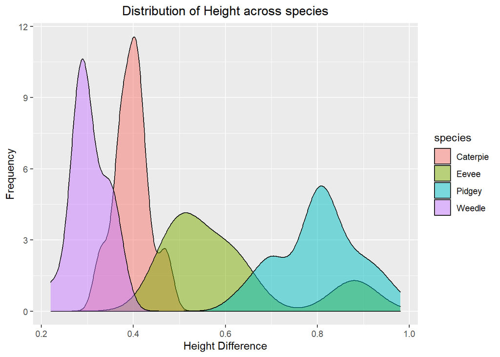

```r
a <- ggplot(df, aes(x=diff_height))

a + geom_density(aes(fill = species), alpha = 0.5) +
  ggtitle("Distribution of Height across species") +
  labs(x = "Height Difference",  y = "Frequency") + theme(plot.title = element_text (hjust = 0.5))
```

## Exercise 2

**2) Recreate the following plot.**

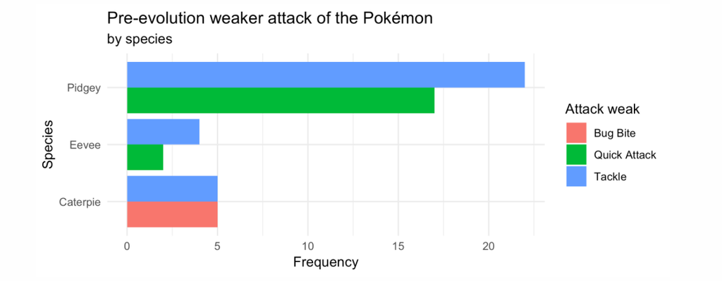

[figure not shown]

```r
selected_species <- filter(df, species != "Weedle")

ggplot(data=selected_species,aes(y=species)) +
geom_histogram(selected_species,mapping=aes(y=species,fill= attack_weak), stat= "count", position = 'dodge')+
ggtitle("Pre-Evolution weaker attack of the pokemon by species") +
labs(x = "Frequency",  y = "Species", fill = "Attack Weak") + theme(plot.title = element_text (hjust = 0.5)) +theme_bw()
```

## Exercise 3

**3) Pick two categorical variables and make a bar plot that depicts the relationship between them. These can be variables from the original data or ones that you create based on the given data.**

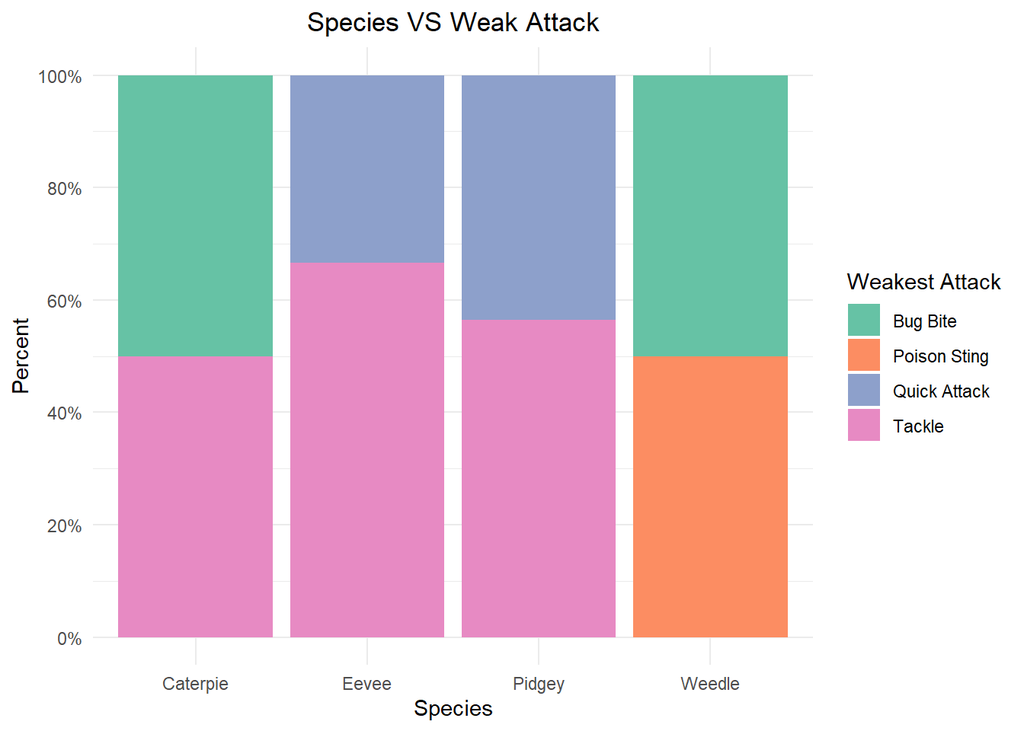

```r
ggplot(df,aes(x= factor(species),fill = factor(attack_weak))) +
  geom_bar(position = "fill") +
  scale_y_continuous(breaks = seq(0, 1, .2),
                     label = percent) +
  scale_fill_brewer(palette = "Set2") +
  labs(y = "Percent",
       fill = "Weakest Attack",
       x = "Species",
       title = "Species VS Weak Attack") +
  theme_minimal() +theme(plot.title = element_text (hjust = 0.5))
```

## Exercise 4

**4) Pick a numerical and a categorical variable, and construct side-by-side box plots depicting the relationship between them.**

[figure not shown]

```r
ggplot(data=df, aes(x=species, y= cp_new, fill= species))+
  geom_boxplot() +
  transition_states( species,
    wrap= FALSE
  ) +
  shadow_mark() +
  enter_grow() +
  ggtitle("Combat Power Post Evolution") +
labs(x = "Species", y = "New Combat Power") + theme_minimal() +theme(plot.title = element_text (hjust = 0.5))
```